# Accumulating results

In this latest “R as it is” (again in collaboration with our friends at Revolution Analytics) we will quickly become expert at efficiently accumulating results in R.

A number of applications (most notably simulation) require the incremental accumulation of results prior to processing. For our example, suppose we want to collect rows of data one by one into a data frame. Take the mkRow function below as a simple example source that yields a row of data each time we call it.

```r
library('microbenchmark')
library('ggplot2')
set.seed(23525) # make run more repeatable
nCol <- 10
timeSeq <- seq.int(100, 2000, 100)
timeSeq <- seq.int(10, 200, 10)
```

Function to populate a row of data.

```r
mkRow <- function(nCol) {
  x <- as.list(rnorm(nCol))
  # make row mixed types by changing first column to string
  x[[1]] <- ifelse(x[[1]]>0,'pos','neg')
  names(x) <- paste('x',seq_len(nCol),sep='.')
  x
}
```

The obvious “for-loop” solution is to collect or accumulate many rows into a data frame by repeated application of rbind. This looks like the following function.

```r
# The common wrong-way to accumulate the rows of data into a single data frame.
mkFrameForLoop <- function(nRow,nCol) {
  d <- c()
  for(i in seq_len(nRow)) {
    ri <- mkRow(nCol)
    di <- data.frame(ri,
                     stringsAsFactors=FALSE)
    d <- rbind(d,di)
  }
  d
}
```

```r
# build function to plot timings
# devtools::install_github("WinVector/WVPlots")
# library('WVPlots')
plotTimings <- function(timings) {
  timings$expr <- reorder(timings$expr,-timings$time,FUN=max)
  ggplot(data=timings,aes(x=nRow,y=time,color=expr)) +
    geom_point(alpha=0.8) + geom_smooth(alpha=0.8)
  nmax <- max(timings$nRow)
  tsub <- timings[timings$nRow==nmax,]
  tsub$expr <- reorder(tsub$expr,tsub$time,FUN=median)
  list(
    ggplot(data=timings,aes(x=nRow,y=time,color=expr)) +
      geom_point(alpha=0.8) + geom_smooth(alpha=0.8),
    ggplot(data=timings,aes(x=nRow,y=time,color=expr)) +
      geom_point(alpha=0.8) + geom_smooth(alpha=0.8) +
      scale_y_log10(),
    WVPlots::ScatterBoxPlot(tsub,'expr','time',
                            title=paste('nRow = ',nmax)) +
      coord_flip()
  )
}
```

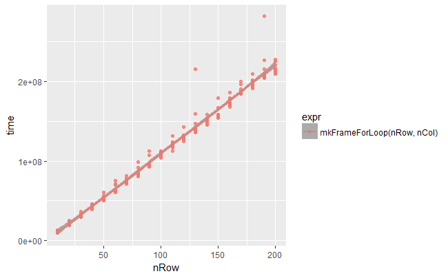

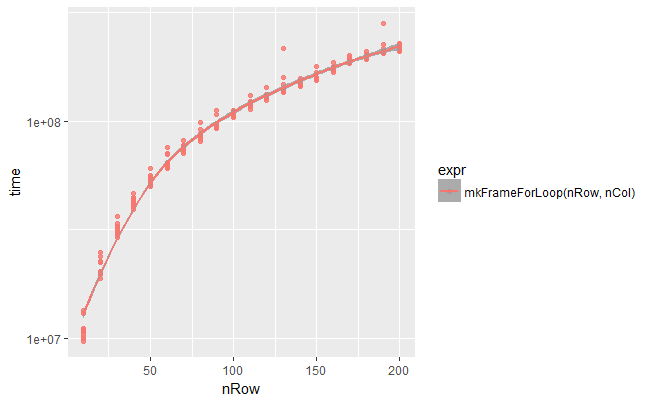

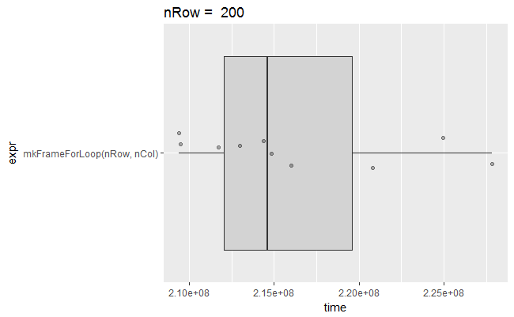

```r
timings <-  vector("list", length(timeSeq))
for(i in seq_len(length(timeSeq))) {
  nRow <- timeSeq[[i]]
  ti <- microbenchmark(
    mkFrameForLoop(nRow,nCol),
    times=10)
  ti <- data.frame(ti,
                   stringsAsFactors=FALSE)
  ti$nRow <- nRow
  ti$nCol <- nCol
  timings[[i]] <- ti
}
timings <- data.table::rbindlist(timings)
print(plotTimings(timings))
```

A few roughly equivilent right ways to accumlate the rows.

```r
# Simplest fix, collect the data in a list and
# grow the list.  Exploits the fact that R can mutate
# common objects when object visibility is limited.
mkFrameForList <- function(nRow,nCol,verbose=FALSE) {
  d <- as.list(seq_len(nRow)) # pre-alloc destination
  for(i in seq_len(nRow)) {
    ri <- mkRow(nCol)
    di <- data.frame(ri,
                     stringsAsFactors=FALSE)
    d[[i]] <- di
    if(verbose) {
      print(pryr::address(d))
    }
  }
  do.call(rbind,d)
}
# Cleanest fix- wrap procedure in a function and
# use lapply.
mkFrameList <- function(nRow,nCol) {
  d <- lapply(seq_len(nRow),function(i) {
    ri <- mkRow(nCol)
    data.frame(ri,
               stringsAsFactors=FALSE)
  })
  do.call(rbind,d)
}
```

Confirm value getting altered in place (effiency depends on interior columns also not chaning address, which is also the case).

```r
mkFrameForList(10,5,TRUE)
```

```
[1] "0x1394a6e8"
[1] "0x1394a6e8"
[1] "0x1394a6e8"
[1] "0x1394a6e8"
[1] "0x1394a6e8"
[1] "0x1394a6e8"
[1] "0x1394a6e8"
[1] "0x1394a6e8"
[1] "0x1394a6e8"
[1] "0x1394a6e8"
```

|  | x.1 | x.2 | x.3 | x.4 | x.5 |
| --- | --- | --- | --- | --- | --- |
| 1 | neg | -0.90800966 | 1.05043254 | 0.07493117 | -1.5031200 |
| 2 | neg | 0.76282592 | -0.15078771 | -0.71118297 | -0.6233542 |
| 3 | neg | 0.97335591 | 0.28815122 | -0.47334941 | -0.9825672 |
| 4 | pos | 0.04508252 | 0.56765240 | -0.39869941 | -1.5970568 |
| 5 | pos | 0.65366459 | -0.90977279 | -1.13687946 | 2.6964289 |
| 6 | neg | 1.10190213 | -0.87134754 | -3.78645623 | 0.6055026 |
| 7 | neg | -2.15357563 | -0.25506138 | -0.10486094 | -0.8455276 |
| 8 | pos | -0.80517150 | 0.10252819 | -0.15855655 | 1.4473021 |
| 9 | pos | -3.40946190 | 0.12691021 | -0.65783384 | -0.5832752 |
| 10 | pos | 0.38187641 | 0.05046661 | -1.13045412 | -0.2741798 |

Get more timings and plots.

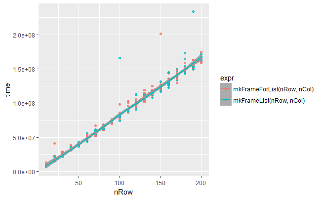

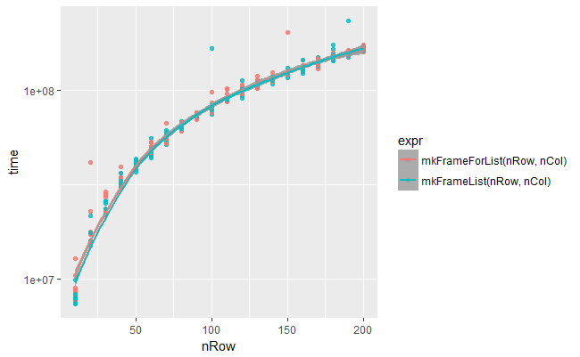

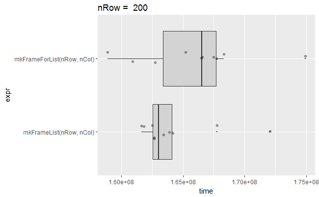

```r
timingsPrev <- timings
timings <-  vector("list", length(timeSeq))
for(i in seq_len(length(timeSeq))) {
  nRow <- timeSeq[[i]]
  ti <- microbenchmark(
    mkFrameForList(nRow,nCol),
    mkFrameList(nRow,nCol),
    times=10)
  ti <- data.frame(ti,
                   stringsAsFactors=FALSE)
  ti$nRow <- nRow
  ti$nCol <- nCol
  timings[[i]] <- ti
}
timings <- data.table::rbindlist(timings)
print(plotTimings(timings))
```

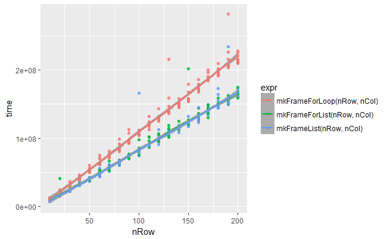

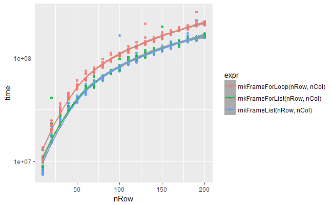

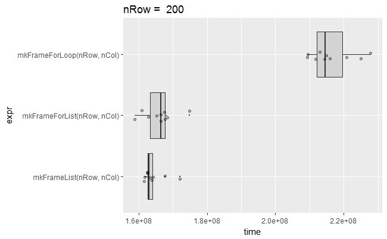

```r
timings <- rbind(timings,timingsPrev)
print(plotTimings(timings))
```

Show the in-place alteration of objects in a simpler setting.

```r
computeSquares <- function(n,
                           messUpVisibility,
                           usePRYR=FALSE) {
  # pre-allocate v
  # (doesn't actually help!)
  v <- 1:n
  if(messUpVisibility) {
     vLast <- v
  }
  # print details of v
  .Internal(inspect(v))
  if(usePRYR) {
    print(pryr::address(v))
  }
  for(i in 1:n) {
    v[[i]] <- i^2
    if(messUpVisibility) {
      vLast <- v
    }
    # print details of v
    .Internal(inspect(v))
    if(usePRYR) {
      print(pryr::address(v))
    }
  }
  v
}
```

Show how if the value associated with v is visible only to the variable name “v” that R will start performing in-place replacement (making calculation much cheaper).

```r
computeSquares(5,FALSE)
```

```
@0x000000001696d3f0 13 INTSXP g0c3 [NAM(1)] (len=5, tl=0) 1,2,3,4,5
@0x00000000145eaf18 14 REALSXP g0c4 [NAM(1)] (len=5, tl=0) 1,2,3,4,5
@0x00000000145eaf18 14 REALSXP g0c4 [NAM(1)] (len=5, tl=0) 1,4,3,4,5
@0x00000000145eaf18 14 REALSXP g0c4 [NAM(1)] (len=5, tl=0) 1,4,9,4,5
@0x00000000145eaf18 14 REALSXP g0c4 [NAM(1)] (len=5, tl=0) 1,4,9,16,5
@0x00000000145eaf18 14 REALSXP g0c4 [NAM(1)] (len=5, tl=0) 1,4,9,16,25
[1]  1  4  9 16 25
```

Show how if the value associated with v is visible to more than one variable that R will not performing in-place replacement (making calcultion much more expensive).

```r
computeSquares(5,TRUE)
```

```
@0x0000000016b13e20 13 INTSXP g0c3 [NAM(2)] (len=5, tl=0) 1,2,3,4,5
@0x0000000014ceaae0 14 REALSXP g0c4 [NAM(2)] (len=5, tl=0) 1,2,3,4,5
@0x0000000014ceab48 14 REALSXP g0c4 [NAM(2)] (len=5, tl=0) 1,4,3,4,5
@0x0000000014ceabb0 14 REALSXP g0c4 [NAM(2)] (len=5, tl=0) 1,4,9,4,5
@0x0000000014ceac80 14 REALSXP g0c4 [NAM(2)] (len=5, tl=0) 1,4,9,16,5
@0x0000000014ceace8 14 REALSXP g0c4 [NAM(2)] (len=5, tl=0) 1,4,9,16,25
[1]  1  4  9 16 25
```

Check if we can use PRYR for addresses in this case.

```r
computeSquares(5,FALSE,usePRYR=TRUE)
```

```
@0x000000001626fec0 13 INTSXP g0c3 [NAM(1)] (len=5, tl=0) 1,2,3,4,5
[1] "0x1626fec0"
@0x0000000016a765d0 14 REALSXP g0c4 [NAM(1)] (len=5, tl=0) 1,2,3,4,5
[1] "0x16a765d0"
@0x0000000016a765d0 14 REALSXP g0c4 [NAM(1)] (len=5, tl=0) 1,4,3,4,5
[1] "0x16a765d0"
@0x0000000016a765d0 14 REALSXP g0c4 [NAM(1)] (len=5, tl=0) 1,4,9,4,5
[1] "0x16a765d0"
@0x0000000016a765d0 14 REALSXP g0c4 [NAM(1)] (len=5, tl=0) 1,4,9,16,5
[1] "0x16a765d0"
@0x0000000016a765d0 14 REALSXP g0c4 [NAM(1)] (len=5, tl=0) 1,4,9,16,25
[1] "0x16a765d0"
[1]  1  4  9 16 25
```

Show slowdown of incremental method versus others as a function of number of row.

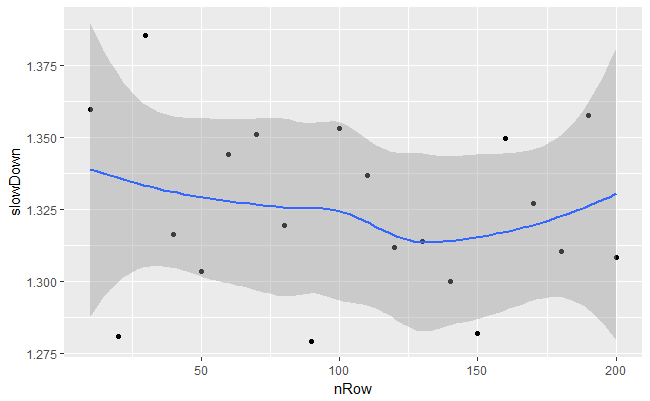

```r
timingsPrev <- timings
timings$isIncremental <- timings$expr=='mkFrameForLoop(nRow, nCol)'
agg <- aggregate(time~isIncremental+nRow,data=timings,FUN=median)
dInc <- agg[agg$isIncremental,]
dInc <- dInc[order(dInc$nRow),]
dRest <- agg[!agg$isIncremental,]
dRest <- dRest[order(dRest$nRow),]
dInc$slowDown <-  dInc$time/dRest$time
ggplot(data=dInc,aes(x=nRow,y=slowDown)) +
  geom_point() + geom_smooth()
```

```r
# From Arun Srinivasan's comment
# http://www.win-vector.com/blog/2015/07/efficient-accumulation-in-r/comment-page-1/#comment-65994
# library('data.table')
mkFrameDataTableFor <- function(nRow, nCol) {
  v = vector("list", nRow)
  for (i in seq_len(nRow)) {
    v[[i]] = mkRow(nCol)
  }
  data.table::rbindlist(v)
}
mkFrameDataTableLapply <- function(nRow, nCol) {
  v <- lapply(seq_len(nRow),function(i) {
    mkRow(nCol)
  })
  data.table::rbindlist(v)
}
# Mucking with environments fix.  Environments
# are mutable and tend to be faster than lists.
mkFrameEnvDataTable <- function(nRow,nCol) {
  e <- new.env(hash=TRUE,parent=emptyenv())
  for(i in seq_len(nRow)) {
    ri <- mkRow(nCol)
    assign(as.character(i),ri,envir=e)
  }
  data.table::rbindlist(as.list(e))
}
# Another possibility, working in place.
mkFrameInPlace <- function(nRow,nCol,classHack=TRUE) {
  r1 <- mkRow(nCol)
  d <- data.frame(r1,
                    stringsAsFactors=FALSE)
  if(nRow>1) {
    d <- d[rep.int(1,nRow),]
    if(classHack) {
      # lose data.frame class for a while
      # changes what S3 methods implement
      # assignment.
      d <- as.list(d)
    }
    for(i in seq.int(2,nRow,1)) {
      ri <- mkRow(nCol)
      for(j in seq_len(nCol)) {
        d[[j]][[i]] <- ri[[j]]
      }
    }
  }
  if(classHack) {
     d <- data.frame(d,stringsAsFactors=FALSE)
  }
  d
}
```

Still more timings.

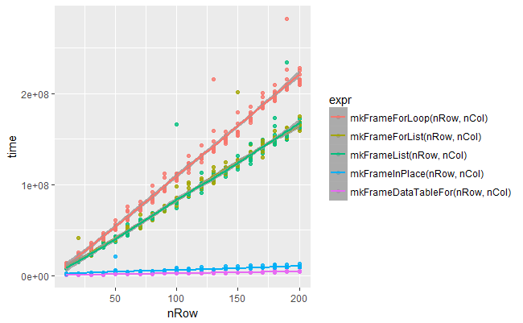

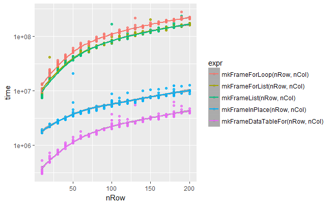

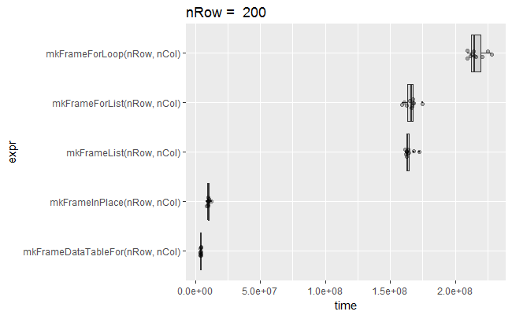

```r
timings <-  vector("list", length(timeSeq))
for(i in seq_len(length(timeSeq))) {
  nRow <- timeSeq[[i]]
  ti <- microbenchmark(
    mkFrameInPlace(nRow,nCol),
    mkFrameDataTableFor(nRow,nCol),
    times=10)
  ti <- data.frame(ti,
                   stringsAsFactors=FALSE)
  ti$nRow <- nRow
  ti$nCol <- nCol
  timings[[i]] <- ti
}
timings <- data.table::rbindlist(timings)
timings <- rbind(timings,timingsPrev)
print(plotTimings(timings))
```

```r
# library('dplyr')
# Fast method from https://twitter.com/drob/status/626146450842497028
mkFrameDplyrBind <- function(nRow,nCol) {
 dplyr::bind_rows(replicate(nRow,
                     data.frame(mkRow(nCol),
                                stringsAsFactors=FALSE),
                     simplify=FALSE))
}
# library('plyr')
# Idiomatic plyr https://www.reddit.com/r/rstats/comments/3ex31f/efficient_accumulation_in_r/ctjl9lq
mkFramePlyrLdply <- function(nRow,nCol) {
  plyr::ldply(seq_len(nRow),
              function(i) data.frame(mkRow(nCol),
                                     stringsAsFactors=FALSE))
}
# try to avoid all storage re-alloc, name checking, and type checking
mkFrameMat <- function(nRow,nCol) {
  r1 <- mkRow(nCol)
  isNum <- vapply(r1,is.numeric,logical(1))
  numIndices <- seq_len(nCol)[isNum]
  strIndices <- seq_len(nCol)[!isNum]
  dN <- matrix(data="",
     nrow=nRow,ncol=length(numIndices))
  dC <- matrix(data="",
     nrow=nRow,ncol=length(strIndices))
  dN[1,] <- as.numeric(r1[numIndices])
  dC[1,] <- as.character(r1[strIndices])
  if(nRow>1) {
    for(i in seq.int(2,nRow,1)) {
      ri <- mkRow(nCol)
      dN[i,] <- as.numeric(ri[numIndices])
      dC[i,] <- as.character(ri[strIndices])
    }
  }
  dN <- data.frame(dN,stringsAsFactors=FALSE)
  names(dN) <- names(r1)[numIndices]
  dC <- data.frame(dC,stringsAsFactors=FALSE)
  names(dC) <- names(r1)[strIndices]
  cbind(dC,dN)
}
# allocate the vectors indpendently
# seems to be avoiding some overhead by not having data.frame class
# (close to current mkFrameInPlace, but faster)
# Adapted from: https://gist.github.com/jimhester/e725e1ad50a5a62f3dee#file-accumulation-r-L43-L57
mkFrameVector <- function(nRow,nCol) {
  r1 <- mkRow(nCol)
  res <- lapply(r1,function(cv) {
    if(is.numeric(cv)) {
      col = numeric(nRow)
    } else {
      col = character(nRow)
    }
    col[[1]] = cv
    col
    })
  if(nRow>1) {
    for(i in seq.int(2,nRow,1)) {
      ri <- mkRow(nCol)
      for(j in seq_len(nCol)) {
        res[[j]][[i]] <- ri[[j]]
      }
    }
  }
  data.frame(res,stringsAsFactors=FALSE)
}
# Efficient method that doesn't need to know how many rows are coming
# devtools::install_github("WinVector/daccum")
# library('daccum')
mkFrameDaccum <- function(nRow,nCol) {
  collector <- daccum::mkColletor()
  for(i in seq_len(nRow)) {
    ri <- mkRow(nCol)
    daccum::collectRows(collector,ri)
  }
  daccum::unwrapRows(collector)
}
```

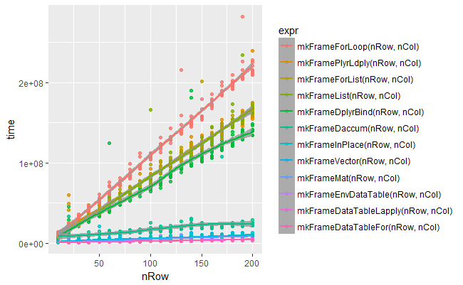

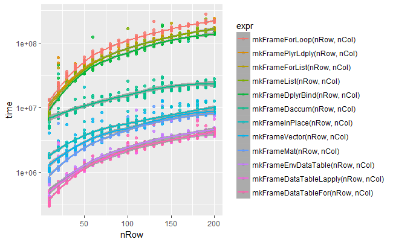

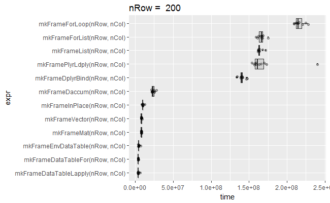

```r
timingsPrev <- timings
timings <-  vector("list", length(timeSeq))
for(i in seq_len(length(timeSeq))) {
  nRow <- timeSeq[[i]]
  ti <- microbenchmark(
    mkFrameDplyrBind(nRow,nCol),
    mkFramePlyrLdply(nRow,nCol),
    mkFrameMat(nRow,nCol),
    mkFrameVector(nRow,nCol),
    mkFrameDaccum(nRow,nCol),
    mkFrameEnvDataTable(nRow,nCol),
    mkFrameDataTableLapply(nRow,nCol),
    times=10)
  ti <- data.frame(ti,
                   stringsAsFactors=FALSE)
  ti$nRow <- nRow
  ti$nCol <- nCol
  timings[[i]] <- ti
}
timings <- data.table::rbindlist(timings, fill = TRUE)
timings <- rbind(timings,timingsPrev)
print(plotTimings(timings))
```